# `figure`

Element

A figure with an optional caption.

Automatically detects its kind to select the correct counting track. For example, figures containing images will be numbered separately from figures containing tables.

## Examples

The example below shows a basic figure with an image:

```
@glacier shows a glacier. Glaciers
are complex systems.

#figure(
  image("glacier.jpg", width: 80%),
  caption: [A curious figure.],
) <glacier>
```

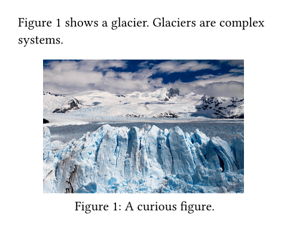

You can also insert tables into figures to give them a caption. The figure will detect this and automatically use a separate counter.

```
#figure(
  table(
    columns: 4,
    [t], [1], [2], [3],
    [y], [0.3s], [0.4s], [0.8s],
  ),
  caption: [Timing results],
)
```

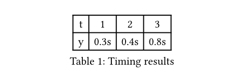

This behaviour can be overridden by explicitly specifying the figure’s `kind`. All figures of the same kind share a common counter.

## Figure behaviour

By default, figures are placed within the flow of content. To make them float to the top or bottom of the page, you can use the `placement` argument.

If your figure is too large and its contents are breakable across pages (e.g. if it contains a large table), then you can make the figure itself breakable across pages as well with this show rule:

```
#show figure: set block(breakable: true)
```

See the block documentation for more information about breakable and non-breakable blocks.

## Caption customization

You can modify the appearance of the figure’s caption with its associated `caption` function. In the example below, we emphasize all captions:

```
#show figure.caption: emph

#figure(
  rect[Hello],
  caption: [I am emphasized!],
)
```

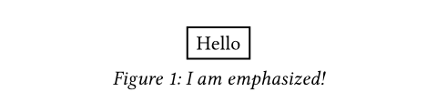

By using a `where` selector, we can scope such rules to specific kinds of figures. For example, to position the caption above tables, but keep it below for all other kinds of figures, we could write the following show-set rule:

```
#show figure.where(
  kind: table
): set figure.caption(position: top)

#figure(
  table(columns: 2)[A][B][C][D],
  caption: [I'm up here],
)
```

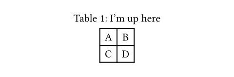

## Accessibility

You can use the `alt` parameter to provide an [alternative description](https://typst.app/docs/guides/accessibility/#textual-representations) of the figure for screen readers and other Assistive Technology (AT). Refer to its documentation to learn more.

You can use figures to add alternative descriptions to paths, shapes, or visualizations that do not have their own `alt` parameter. If your graphic is purely decorative and does not have a semantic meaning, consider wrapping it in `pdf.artifact` instead, which will hide it from AT when exporting to PDF.

AT will always read the figure at the point where it appears in the document, regardless of its `placement`. Put its markup where it would make the most sense in the reading order.

## Parameters

```
figure(
  content,
  alt: none or str,
  placement: none or auto or alignment,
  scope: str,
  caption: none or content,
  kind: auto or str or function,
  supplement: none or auto or content or function,
  numbering: none or str or function,
  gap: length,
  outlined: bool,
) → content
```

### `body`

content Required Positional

The content of the figure. Often, an image.

### `alt`

none or str Settable

Default: `none`

An alternative description of the figure.

When you add an alternative description, AT will read both it and the caption (if any). However, the content of the figure itself will be skipped.

When the body of your figure is an image with its own `alt` text set, this parameter should not be used on the figure element. Likewise, do not use this parameter when the figure contains a table, code, or other content that is already accessible. In such cases, the content of the figure will be read by AT, and adding an alternative description would lead to a loss of information.

You can learn how to write good alternative descriptions in the [Accessibility Guide](https://typst.app/docs/guides/accessibility/#textual-representations).

### `placement`

none or auto or alignment Settable

Default: `none`

The figure’s placement on the page.

- `none`: The figure stays in-flow exactly where it was specified like other content.
- `auto`: The figure picks `top` or `bottom` depending on which is closer.
- `top`: The figure floats to the top of the page.
- `bottom`: The figure floats to the bottom of the page.

The gap between the main flow content and the floating figure is controlled by the `clearance` argument on the `place` function.

**View example**

```
#set page(height: 200pt)
#show figure: set place(
  clearance: 1em,
)

= Introduction
#figure(
  placement: bottom,
  caption: [A glacier],
  image("glacier.jpg", width: 60%),
)
#lorem(60)
```

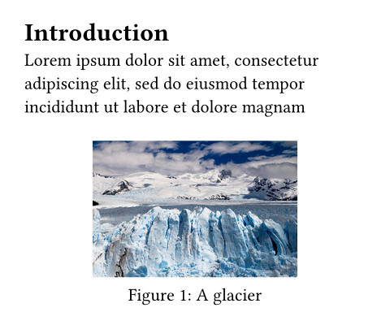

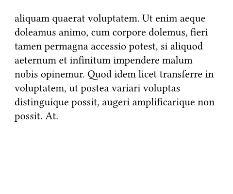

### `scope`

str Settable

Default: `"column"`

Relative to which containing scope the figure is placed.

Set this to `"parent"` to create a full-width figure in a two-column document.

Has no effect if `placement` is `none`.

**View example**

```
#set page(height: 250pt, columns: 2)

= Introduction
#figure(
  placement: bottom,
  scope: "parent",
  caption: [A glacier],
  image("glacier.jpg", width: 60%),
)
#lorem(60)
```

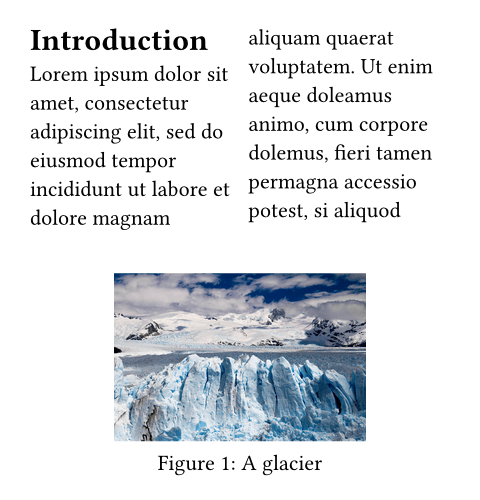

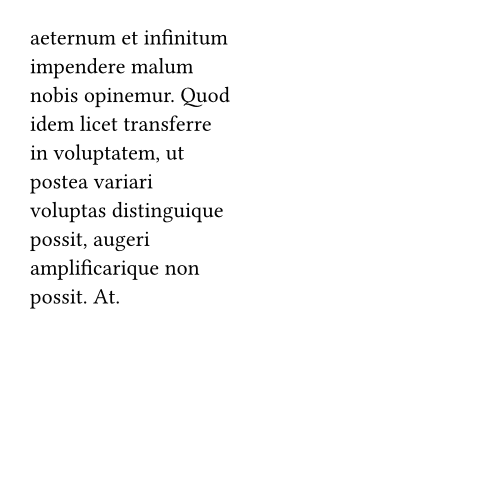

| **Variant** | **Details** |
| --- | --- |
| `"column"` | Place into the current column. |
| `"parent"` | Place relative to the parent, letting the content span over all columns. |

### `caption`

none or content Settable

Default: `none`

The figure’s caption.

### `kind`

auto or str or function Settable

Default: `auto`

The kind of figure this is.

All figures of the same kind share a common counter.

If set to `auto`, the figure will try to automatically determine its kind based on the type of its body. Automatically detected kinds are tables and code. In other cases, the inferred kind is that of an image.

Setting this to something other than `auto` will override the automatic detection. This can be useful if

- you wish to create a custom figure type that is not an image, a table or code,
- you want to force the figure to use a specific counter regardless of its content.

You can set the kind to be an element function or a string. If you set it to an element function other than `table`, `raw`, or `image`, you will need to manually specify the figure’s supplement.

**View example: Customizing the figure kind**

```
#figure(
  circle(radius: 10pt),
  caption: [A curious atom.],
  kind: "atom",
  supplement: [Atom],
)
```

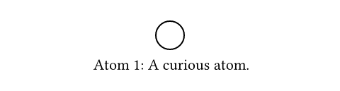

If you want to modify a counter to skip a number or reset the counter, you can access the counter of each kind of figure with a `where` selector:

- For tables: `counter(figure.where(kind: table))`
- For images: `counter(figure.where(kind: image))`
- For a custom kind: `counter(figure.where(kind: kind))`

**View example: Modifying the figure counter for specific kinds**

```
#figure(
  table(columns: 2, $n$, $1$),
  caption: [The first table.],
)

#counter(
  figure.where(kind: table)
).update(41)

#figure(
  table(columns: 2, $n$, $42$),
  caption: [The 42nd table],
)

#figure(
  rect[Image],
  caption: [Does not affect images],
)
```

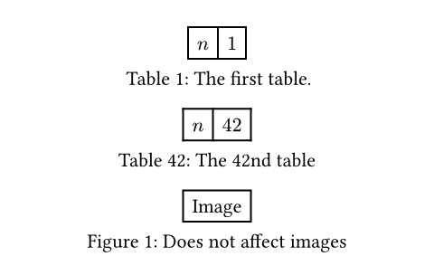

To conveniently use the correct counter in a show rule, you can access the `counter` field. There is an example of this in the documentation of the `figure.caption` element’s `body` field.

### `supplement`

none or auto or content or function Settable

Default: `auto`

The figure’s supplement.

If set to `auto`, the figure will try to automatically determine the correct supplement based on the `kind` and the active text language. If you are using a custom figure type, you will need to manually specify the supplement.

If a function is specified, it is passed the first descendant of the specified `kind` (typically, the figure’s body) and should return content.

**View example**

```
#figure(
  [The contents of my figure!],
  caption: [My custom figure],
  supplement: [Bar],
  kind: "foo",
)
```

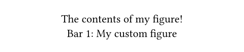

### `numbering`

none or str or function Settable

Default: `"1"`

How to number the figure. Accepts a numbering pattern or function taking a single number.

### `gap`

length Settable

Default: `0.65em`

The vertical gap between the body and caption.

### `outlined`

bool Settable

Default: `true`

Whether the figure should appear in an `outline` of figures.

## Definitions

### `caption`

Element

The caption of a figure. This element can be used in set and show rules to customize the appearance of captions for all figures or figures of a specific kind.

In addition to its `position` and `body`, the `caption` also provides the figure’s `kind`, `supplement`, `counter`, and `numbering` as fields. These parts can be used in `where` selectors and show rules to build a completely custom caption.

**View example**

```
#show figure.caption: emph

#figure(
  rect[Hello],
  caption: [A rectangle],
)
```

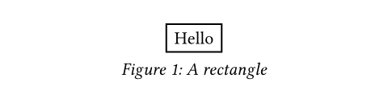

```
figure.caption(
  position: alignment,
  separator: auto or content,
  content,
) → content
```

#### `position`

alignment Settable

Default: `bottom`

The caption’s position in the figure. Either `top` or `bottom`.

**View example**

```
#show figure.where(
  kind: table
): set figure.caption(position: top)

#figure(
  table(columns: 2)[A][B],
  caption: [I'm up here],
)

#figure(
  rect[Hi],
  caption: [I'm down here],
)

#figure(
  table(columns: 2)[A][B],
  caption: figure.caption(
    position: bottom,
    [I'm down here too!]
  )
)
```

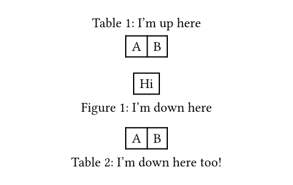

#### `separator`

auto or content Settable

Default: `auto`

The separator which will appear between the number and body.

If set to `auto`, the separator will be adapted to the current language and region.

**View example**

```
#set figure.caption(separator: [ --- ])

#figure(
  rect[Hello],
  caption: [A rectangle],
)
```

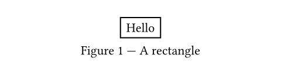

#### `body`

content Required Positional

The caption’s body.

Can be used alongside `kind`, `supplement`, `counter`, `numbering`, and `location` to completely customize the caption.

**View example**

```
#show figure.caption: it => [
  #underline(it.body) |
  #it.supplement
  #context it.counter.display(it.numbering)
]

#figure(
  rect[Hello],
  caption: [A rectangle],
)
```

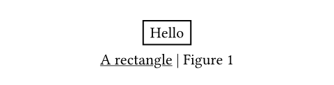

© Typst GmbH and contributors  
Licensed under the Apache License, Version 2.0.  
https://typst.app/docs/reference/model/figure/